# Class Eight: Multinomial and ordinal logistic regression

Xiaoyan Wang

Mar 4th, 2020

# Learning objectives

- Understand what multinomial and ordinal logistic regressions are
- Know the assumptions of multinomial and ordinal logistic regressions
- Be able to use R to perform multinomial and ordinal logistic regressions
- Know how to perform hypothesis tests
- Know how to estimate and interpret estimates from multinomial and ordinal regression models

# What is multinomial logistic regression (MLR)?

- A form of logistic regression analysis conducted when the dependent variable is nominal with more than two levels (e.g., insurance status, occupation).
- Also known as multinomial logit model, polytomous logistic regression, multiclass logistic regression, softmax regression, the maximum entropy classifier, and the conditional maximum entropy model.
- Used to describe data and to explain the relationship between one dependent nominal variable and one or more independent variables.

# Crucial features

- Suppose our dependent nominal variable y has J levels.
- Estimate a separate binary logistic regression model for each non-reference level of y compared to the reference level of y, therefore the result is J-1 binary logistic regression models.
- Each model conveys the effect of predictors on the probability of success in a non-reference level of y, in comparison to the reference level.

# Link function

- Take the logarithm of the odds of the probability of y=m versus the probability of y=b, where b is the reference outcome whose coefficients associated with the independent variables are constrained to be zero and m is the target outcome.

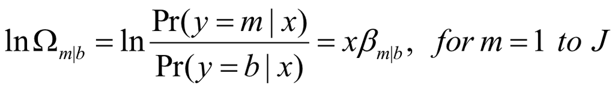

The link function

# Structural model

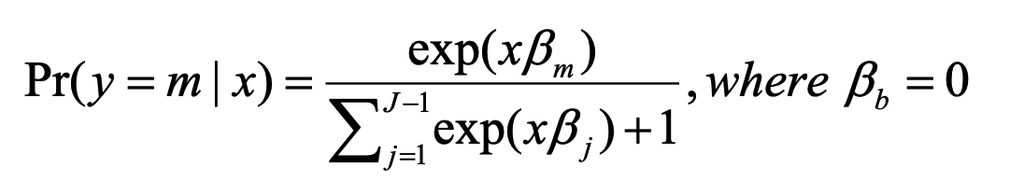

The structural model

# Assumptions

- Dependent variable is nominal with more than two levels
- Independence of observations
- No multicollinearity
- A linear relationship between any continuous independent variables and the logit transformation of the dependent variable
- No outliers or highly influential points (Pregibon’s (1981) deltabeta or Cook’s distance)

# Example

- Prostate cancer data was downloaded from the Surveillance, Epidemiology, and End Results Program (SEER) database, a premier data source for cancer statistics in the US. SEER collects incidence, prevalence and survival data.
- Patients with primary prostate cancer, aged above 18 years with Stage I to IV at diagnosis were included.
- In this study, we are interested in the effects of insurance status on stage at diagnosis among prostate cancer patients.
- The covariates are comprised of patients’ demographics, marital status, and SES.

# Get the data and load libraries

```r
#install packages
packages <- c("readr", "tidyverse", "nnet", "MASS", "funModeling", "brant")
#install.packages(packages)

#Load libraries
library(readr) #for read txt file
library(tidyverse) # for various packages
library(nnet) #Multinomial logistic regresison
library(MASS) #Ordinal logistic regression
library(funModeling) #for describe function
library(brant) #for testing parallel regression assumption

#Most efficient way
#install.packages("pacman")
pacman::p_load(readr, tidyverse, nnet, MASS, funModeling, brant)

#read in the data
Class8 <- read_delim("prostate_SEER.txt", "\t")
```

# Data Management

```r
##Look at the data
names(Class8)<-c("PatientID", "Age", "FirstCancer", "Sex", "Diagnosis_year", "Insurance", "Marital_status", "Race_ethnicity", "Poverty", "Stage")
##Look at the variables will be used
##taking a quick look
describe(Class8)
```

```
## Class8
##
##  10  Variables      50310  Observations
## ---------------------------------------------------------------------------
## PatientID
##        n  missing distinct
##    50310        0    50306
##
## lowest : 00000712 00003256 00005074 00015104 00017764
## highest: 77801429 77801434 77801447 77801507 77801600
## ---------------------------------------------------------------------------
## Age
##        n  missing distinct
##    50310        0       54
##
## lowest : 24 years  29 years  32 years  33 years  34 years
## highest: 81 years  82 years  83 years  84 years  85+ years
## ---------------------------------------------------------------------------
## FirstCancer
##        n  missing distinct
##    50310        0        2
##
## Value         No   Yes
## Frequency   4463 45847
## Proportion 0.089 0.911
## ---------------------------------------------------------------------------
## Sex
##        n  missing distinct    value
##    50310        0        1     Male
##
## Value       Male
## Frequency  50310
## Proportion     1
## ---------------------------------------------------------------------------
## Diagnosis_year
##        n  missing distinct     Info     Mean      Gmd
##    50310        0        1        0     2015        0
##
## Value       2015
## Frequency  50310
```

[output cut: 28 more lines]

```
## Poverty
##        n  missing distinct
##    50310        0      536
##
## lowest : 00174    00309    00311    00314    00321
## highest: 03627    03712    03835    04145    Blank(s)
## ---------------------------------------------------------------------------
## Stage
##        n  missing distinct
##    50296       14        5
##
## Value              I        II       III        IV UNK Stage
## Frequency        767     34699      4385      5654      4791
## Proportion     0.015     0.690     0.087     0.112     0.095
## ---------------------------------------------------------------------------
```

```r
#Recode the character variables to numeric variables and rocode the factor variables
Data <- Class8 %>%
   mutate(Age_num = parse_number(Age),
         #Non-Hispanic White as reference
         Race_cat = case_when(Race_ethnicity %in% c("Non-Hispanic Unknown Race",
                                                   "Non-Hispanic American Indian/Alaska Native",
                                                   "Non-Hispanic Asian or Pacific Islander") ~ "Non-Hispanic Other",
                             TRUE ~ Race_ethnicity),
         Race_cat = factor(Race_cat),
         Race_cat = relevel(Race_cat, ref = "Non-Hispanic White"),
         #Stage
         Stage_cat = replace(Stage, Stage == "UNK Stage", NA),
         Stage_cat = factor(Stage_cat),
         #Medicaid as reference
         Insur_cat = case_when(Insurance %in% c("Insured",
                                                "Insured/No specifics")  ~ "Private insurance",
                               Insurance == "Any Medicaid" ~ "Medicaid"),
         Insur_cat = factor(Insur_cat),
         Insur_cat = relevel(Insur_cat, ref = "Medicaid"),
         #Marital status: Married as reference
         Marital_cat = case_when(Marital_status %in% c("Divorced",
                                                     "Separated",
                                                     "Single (never married)",
                                                     "Unmarried or Domestic Partner",
                                                     "Widowed") ~ "Single",
                               Marital_status == "Married (including common law)" ~ "Married"),
         Marital_cat = factor(Marital_cat),
         Marital_cat = relevel(Marital_cat, ref = "Married"),
         #Poverty level: Low poverty as reference
         Poverty = as.numeric(Poverty),
         Poverty_cat = ifelse(Poverty < median(Poverty, na.rm = T), "Low poverty", "High poverty"),
         Poverty_cat = factor(Poverty_cat),
         Poverty_cat = relevel(Poverty_cat, ref = "Low poverty")) %>%
  #Keep primary cancer cases only
  filter(FirstCancer=="Yes")
```

### Drop the cases with missing values on any variables used for complete case analysis

```r
Complete <- Data %>%
  dplyr::select(Age_num : Poverty_cat) %>%
  drop_na()

MissingRate <-  1- nrow(Complete)/nrow(Data)
#Look at missing rate
MissingRate
```

```
## [1] 0.2696796
```

# Execute a mutilnomial logistic regression

### Below we use the multinom function from the *nnet* package to estimate a multinomial logistic regression model.

```r
#Attach the data to avoid repeatly typing the dataset name
attach(Complete)
##Re-leveling data, choose stage IV as reference
Stage_cat_re <- relevel(Stage_cat, ref = "IV")

mod <- multinom(Stage_cat_re ~ Insur_cat)
summary(mod)
```

```
## Call:
## multinom(formula = Stage_cat_re ~ Insur_cat)
##
## Coefficients:
##     (Intercept) Insur_catPrivate insurance
## I    -2.3441817                  0.4046260
## II    1.0388912                  0.6987445
## III  -0.8359928                  0.7059517
##
## Std. Errors:
##     (Intercept) Insur_catPrivate insurance
## I    0.14245559                 0.14922858
## II   0.04903894                 0.05193101
## III  0.07664437                 0.08003431
##
## Residual Deviance: 54919.71
## AIC: 54931.71
```

# Interpretations

- *Categorical variable*
- The log odds of being diagnosed at stage I vs. stage IV increased by 0.40 in cases with private insurance compared to those with Medicaid.
- The log odds of being diagnosed at stage II vs. stage IV increased by 0.70 in cases with private insurance compared to those with Medicaid.
- The log odds of being diagnosed at stage III vs. stage IV increased by 0.71 in cases with private insurance compared to those with Medicaid.

# Interpretations (con.)

- To know the effect of *Insured* on the logit of a non-reference outcome relative to another non-refernce outcome (e.g.,stage II vs. stage III)), you can take the difference of the two *coefficients* (0.6987445-0.7059517=-0.0072072).
- Meaning: the log odds of being diagnosed in stage II vs. stage III decreased by 0.007 in those with private insurance compared to those with Medicaid.
- You can *also* just relevel the reference category as stage II.

# Interpretations (con.)

- Even though 1 set of coefficients is omitted, there are actually more sets of coefficients that we can calculate with simple math. For a model with four outcomes in our case, we have 6 sets of comparisons (i.e., 6 sets of coefficients):
- - stage IV vs III, stage IV vs II, stage IV vs I
- - stage III vs II, stage III vs I
- - stage II vs I

# Hypothesis test

- No p values are automatically reported in the multinom function.
- Use Z-test to test individual parameter (i.e. β).
- The p-value from this test indicates whether or not we can reject the null hypothesis of β equal to 0 relative to the effect on the reference outcome at a given level of statistical significance (e.g., 0.05).

```r
#calculate z score
z <- summary(mod)$coefficients/summary(mod)$standard.errors
# 2-tailed Z test
p <- (1 - pnorm(abs(z), 0, 1))*2
p
```

```
##     (Intercept) Insur_catPrivate insurance
## I             0                0.006698935
## II            0                0.000000000
## III           0                0.000000000
```

```r
#Get confidence intervals for the log odds using confint function
ci <- confint(mod)
ci
```

```
## , , I
##
##                                 2.5 %     97.5 %
## (Intercept)                -2.6233895 -2.0649739
## Insur_catPrivate insurance  0.1121434  0.6971087
##
## , , II
##
##                                2.5 %    97.5 %
## (Intercept)                0.9427766 1.1350057
## Insur_catPrivate insurance 0.5969616 0.8005274
##
## , , III
##
##                                 2.5 %     97.5 %
## (Intercept)                -0.9862130 -0.6857726
## Insur_catPrivate insurance  0.5490874  0.8628161
```

# Odds ratio and 95% CIs

- Odds ratio can be taken and interpreted in the same way as that from a binary logistic model: OR=exp(β).

```r
## extract the coefficients from the model and exponentiate to get OR
exp(coef(mod))
```

```
##     (Intercept) Insur_catPrivate insurance
## I    0.09592567                   1.498742
## II   2.82608166                   2.011226
## III  0.43344393                   2.025774
```

```r
#get confidence intervals for ORs
exp(confint(mod, level=0.95))
```

```
## , , I
##
##                                 2.5 %    97.5 %
## (Intercept)                0.07255651 0.1268216
## Insur_catPrivate insurance 1.11867327 2.0079387
##
## , , II
##
##                               2.5 %   97.5 %
## (Intercept)                2.567099 3.111191
## Insur_catPrivate insurance 1.816591 2.226715
##
## , , III
##
##                                2.5 %    97.5 %
## (Intercept)                0.3729865 0.5037009
## Insur_catPrivate insurance 1.7316719 2.3698250
```

# Interpretations

- *Categorical variable*
- The odds of being diagnosed with stage I prostate cancer relative to stage IV is 1.5 times greater for privately insured cases versus those with Medicaid.

# MLR vs. Binary logistic regression

- MLR estimates a separate binary logistic regression model for each level of y compared to the reference level of y, therefore the result is a chain of binary logistic regression models.
- The binary logistic regression results are shown for the comparisons that only includes the cases with stage I and IV with stage IV as reference category.

```r
#Drop the cases with stage II and stage III
bi_logit <- Complete %>%
  filter (Stage_cat %in% c("I", "IV")) %>%
  mutate (Stage_cat_re =relevel(Stage_cat, ref = "IV"))

#Run a binary logistic regression using stage IV as the reference category
mod_bi <- glm(Stage_cat_re ~ Insur_cat, data=bi_logit,family=binomial())

#Get the odds ratio and 95%CIs
exp(cbind("Odds ratio" = coef(mod_bi), confint(mod_bi, level = 0.95)))
```

```
##                            Odds ratio      2.5 %    97.5 %
## (Intercept)                0.09591476 0.07173243 0.1255226
## Insur_catPrivate insurance 1.49903401 1.12917416 2.0290845
```

# Compared with the multinomial logistic regression

- The results are pretty similar.

```r
#Extract the results for the comparison group of stage I and stage IV only
exp(coef(mod)[1,])
```

```
##                (Intercept) Insur_catPrivate insurance
##                 0.09592567                 1.49874193
```

```r
#confidence intervals
exp(confint(mod, level=0.95)[1:2,1:2,1])
```

```
##                                 2.5 %    97.5 %
## (Intercept)                0.07255651 0.1268216
## Insur_catPrivate insurance 1.11867327 2.0079387
```

# Adding potential confounders

```r
##Execute a mutilnomial regression with insurance as independent variable and demographics as covariates
mod_c <- multinom(Stage_cat_re ~ Insur_cat + Age_num + Race_cat + Marital_cat + Poverty_cat)
summary(mod_c)
```

```
## Call:
## multinom(formula = Stage_cat_re ~ Insur_cat + Age_num + Race_cat +
##     Marital_cat + Poverty_cat)
##
## Coefficients:
##     (Intercept) Insur_catPrivate insurance     Age_num
## I     -3.258638                  0.1047056  0.01984497
## II     4.734798                  0.6960841 -0.05306447
## III    4.287052                  0.6525154 -0.07264631
##     Race_catHispanic (All Races) Race_catNon-Hispanic Black
## I                     -0.4319383                -0.58410775
## II                    -0.2084422                 0.07434071
## III                   -0.1743919                -0.41592181
##     Race_catNon-Hispanic Other Marital_catSingle Poverty_catHigh poverty
## I                  -0.58495596        -0.4016670             0.117963374
## II                 -0.10439985        -0.3922940             0.025006982
## III                -0.06231411        -0.5335841             0.001420419
##
## Std. Errors:
##     (Intercept) Insur_catPrivate insurance     Age_num
## I     0.3844336                 0.15556027 0.005007069
## II    0.1423103                 0.05536010 0.001927801
## III   0.1944495                 0.08420577 0.002653770
##     Race_catHispanic (All Races) Race_catNon-Hispanic Black
## I                     0.15488597                 0.15157236
## II                    0.05488506                 0.04810276
## III                   0.07484066                 0.06963991
##     Race_catNon-Hispanic Other Marital_catSingle Poverty_catHigh poverty
## I                   0.19504229        0.09891417              0.08685912
## II                  0.06461014        0.03599641              0.03374014
## III                 0.08785748        0.05186115              0.04581218
##
## Residual Deviance: 53458.26
## AIC: 53506.26
```

```r
## extract the coefficients from the model and exponentiate
exp(coef(mod_c))
```

```
##      (Intercept) Insur_catPrivate insurance   Age_num
## I     0.03844072                   1.110384 1.0200432
## II  113.84049574                   2.005882 0.9483189
## III  72.75168373                   1.920365 0.9299297
##     Race_catHispanic (All Races) Race_catNon-Hispanic Black
## I                      0.6492494                  0.5576032
## II                     0.8118480                  1.0771738
## III                    0.8399677                  0.6597319
##     Race_catNon-Hispanic Other Marital_catSingle Poverty_catHigh poverty
## I                    0.5571304         0.6692035                1.125203
## II                   0.9008650         0.6755055                1.025322
## III                  0.9395877         0.5864991                1.001421
```

```r
#confidence intervals (efficient method, all)
exp(confint(mod_c, level=0.95))
```

```
## , , I
##
##                                  2.5 %     97.5 %
## (Intercept)                  0.0180951 0.08166237
## Insur_catPrivate insurance   0.8185778 1.50621243
## Age_num                      1.0100818 1.03010284
## Race_catHispanic (All Races) 0.4792614 0.87953021
## Race_catNon-Hispanic Black   0.4142921 0.75048818
## Race_catNon-Hispanic Other   0.3801339 0.81653941
## Marital_catSingle            0.5512674 0.81237045
## Poverty_catHigh poverty      0.9490656 1.33402957
##
## , , II
##
##                                   2.5 %      97.5 %
## (Intercept)                  86.1315043 150.4636262
## Insur_catPrivate insurance    1.7996285   2.2357749
## Age_num                       0.9447425   0.9519088
## Race_catHispanic (All Races)  0.7290486   0.9040511
## Race_catNon-Hispanic Black    0.9802585   1.1836707
## Race_catNon-Hispanic Other    0.7937130   1.0224827
## Marital_catSingle             0.6294898   0.7248850
## Poverty_catHigh poverty       0.9597116   1.0954185
##
## , , III
##
##                                   2.5 %      97.5 %
## (Intercept)                  49.6966749 106.5022459
## Insur_catPrivate insurance    1.6282001   2.2649568
## Age_num                       0.9251054   0.9347791
## Race_catHispanic (All Races)  0.7253675   0.9726734
## Race_catNon-Hispanic Black    0.5755590   0.7562146
## Race_catNon-Hispanic Other    0.7909570   1.1161479
## Marital_catSingle             0.5298136   0.6492495
## Poverty_catHigh poverty       0.9154223   1.0954997
```

# Interpretations

- *Continous variable*
- The odds of being diagnosed with stage I prostate cancer relative to stage IV is 1.02 times greater with each one-year increases in age, holding all other variables constant.
- *Categorical variable*
- The odds of being diagnosed with stage I prostate cancer relative to stage IV is 1.11 times greater for privately insured cases versus those with Medicaid, holding all other variables constant.

# Overview of ordinal outcome variables

- Key features of an ordinal variable: it does have a ranking order, but distances between levels are not measurable (e.g. for pain: none, mild, moderate, severe)
- Applying an OLS regression to an ordinal outcome variable is a fatal error
- Alternative models
  - - Binary logistic regression to collapse categories to create a dichotomous outcome
  - - Multinomial logistic regression to ignore the ranking order by treating the outcome as a nominal variable

# Ordinal logistic regression

- Ordinal regression is used to predict the dependent variable with ordered multiple categories (e.g., stage, likert scale) and independent variables.
- Also known as ordinal logit model, ordered logit model, and proportional odds model.

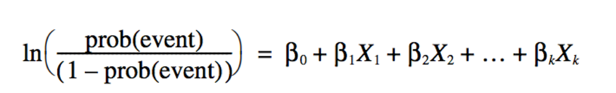

Model link function

# Assumptions

- Dependent variable should be ordinal variables with more than two levels.
- There is no multicollinearity.
- Have proportional odds or parallel regression.

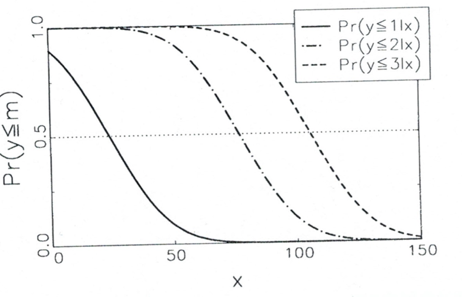

Parallel regression assumption

# Execute an ordinal logistic regression

```r
mod1 <- polr(Stage_cat ~ Insur_cat,Hess=TRUE)

summary(mod1)
```

```
## Call:
## polr(formula = Stage_cat ~ Insur_cat, Hess = TRUE)
##
## Coefficients:
##                              Value Std. Error t value
## Insur_catPrivate insurance -0.4529    0.04431  -10.22
##
## Intercepts:
##        Value    Std. Error t value
## I|II    -4.3752   0.0580   -75.3705
## II|III   0.6806   0.0425    16.0039
## III|IV   1.4236   0.0434    32.8226
##
## Residual Deviance: 54990.37
## AIC: 54998.37
```

# Hypothesis test

- Use Z-test to test individual parameter
- The p-value from such test indicates whether or not we can reject the null hypothesis of β equal to 0 at a given level of statistical significance.

```r
## store table
ctable <- coef(summary(mod1))
## calculate and store p values
p <- pnorm(abs(ctable[, "t value"]), lower.tail = FALSE) * 2
p
```

```
## Insur_catPrivate insurance                       I|II
##               1.614731e-24               0.000000e+00
##                     II|III                     III|IV
##               1.200988e-57              2.800579e-236
```

```r
## combined table
ctable <- cbind(ctable, "p value" = p)
ctable
```

```
##                                 Value Std. Error   t value       p value
## Insur_catPrivate insurance -0.4528736 0.04431283 -10.21992  1.614731e-24
## I|II                       -4.3751629 0.05804874 -75.37050  0.000000e+00
## II|III                      0.6805588 0.04252468  16.00386  1.200988e-57
## III|IV                      1.4236127 0.04337291  32.82263 2.800579e-236
```

```r
# default method gives profiled CIs
ci <- confint(mod1)
ci
```

```
##      2.5 %     97.5 %
## -0.5393816 -0.3656608
```

# Get the odds ratio and 95%CIs

```r
## odds ratios and 95%CIs
exp(cbind("Odds ratio" = coef(mod1), confint.default(mod1, level = 0.95)))
```

```
##                            Odds ratio     2.5 %    97.5 %
## Insur_catPrivate insurance  0.6357985 0.5829084 0.6934875
```

# Interpretations

- Exp(β) above was estimated, meaning compare odds from low to high.
- *Categorical variable*
- The odds of being diagnosed at stage IV are 0.64 times the odds of being diagnosed at *stages III to I* for patients with private insurance than those with Medicaid.
- *or*
- The odds of being diagnosed at *stage IV and III* are 0.64 times the odds of being diagnosed at *stages II and I* for patients with private insurance than those with Medicaid.
- *or*
- The odds of being diagnosed at *stage IV to II* are 0.64 times the odds of being diagnosed at *stages I* for patients with private insurance than those with Medicaid.

# Interpretations

- If the Exp(-β) above was estimated, meaning compare odds from high to low.

```r
## odds ratios and 95%CIs
exp(cbind("Odds ratio" = -coef(mod1)))
```

```
##                            Odds ratio
## Insur_catPrivate insurance   1.572825
```

# Interpretations

- *Categorical variable*
- The odds of being diagnosed at stage I are 1.57 times the odds of being diagnosed at *stages II to IV* for patients with private insurance than those with Medicaid.
- *or*
- The odds of being diagnosed at *stage I and II* are 1.57 times the odds of being diagnosed at *stages III and IV* for patients with private insurance than those with Medicaid.
- *or*
- The odds of being diagnosed at *stage I to III* are 1.57 times the odds of being diagnosed at *stages IV* for patients with private insurance than those with Medicaid.

# Execute an ordinal logistic regression with potential confounders

```r
mod1_c <- polr(Stage_cat ~ Insur_cat + Age_num + Race_cat + Marital_cat + Poverty_cat, Hess=TRUE)
## odds ratios and 95%CIs
exp(cbind("Odds ratio" = coef(mod1_c), confint.default(mod1_c, level = 0.95)))
```

```
##                              Odds ratio     2.5 %    97.5 %
## Insur_catPrivate insurance    0.6521232 0.5958743 0.7136818
## Age_num                       1.0185506 1.0156618 1.0214476
## Race_catHispanic (All Races)  1.1738816 1.0818171 1.2737810
## Race_catNon-Hispanic Black    0.8546282 0.7962841 0.9172473
## Race_catNon-Hispanic Other    1.1227575 1.0204769 1.2352894
## Marital_catSingle             1.2236577 1.1581431 1.2928783
## Poverty_catHigh poverty       0.9668566 0.9204544 1.0155979
```

# Interpretations

- Exp(β) above was estimated, meaning compare odds from low to high.
- Examples
- *Continous variable*
- The odds of being diagnosed at *stage IV* is 1.02 times the Odds of being diagnosed at *stages I to III* with each one-year increases in age, holding all other variables constant. *or*
- The odds of being diagnosed at *stages IV and III* is 1.02 times the odds of being diagnosed at *stages I and II* with each one-year increase in age, holding all other variables constant. *or*
- The odds of being diagnosed at *stages IV to II* is 1.02 times the odds of being diagnosed at *stage I* with each one-year increase in age, holding all other variables constant.

# Interpretations

- *Categorical variable*
- The odds of being diagnosed at stage IV are 0.65 times the odds of being diagnosed at *stages III to I* for patients with private insurance than those with Medicaid at diagnosis, holding all other variables constant. *or*
- The odds of being diagnosed at *stages IV and III* are 0.65 times the odds of being diagnosed at *stages II and I* for patients with private insurance than those with Medicaid at diagnosis, holding other variables constant. *or*
- The odds of being diagnosed at *stages IV to II* are 0.65 times the odds of being diagnosed at *stage I* for patients with private insurance than those with Medicaid at diagnosis, holding other variables constant.

# Testing the parallel regression assumption using Brant Test

- Published by Rollin Brant in 1990.
- Brant Test assesses whether the observed deviations from the Ordinal Logistic Regression model are larger than what could be attributed to chance alone.
- In conjunction with polr function.
- If the probability is greater than alpha level (0.05), then the dataset satisfies the proportional odds assumption.

```r
#Univariate model
brant(mod1)
```

```
## ------------------------------------------------------------
## Test for         X2  df  probability
## ------------------------------------------------------------
## Omnibus              86.64   2   0
## Insur_catPrivate insurance   86.64   2   0
## ------------------------------------------------------------
##
## H0: Parallel Regression Assumption holds
```

```
##                                  X2 df  probability
## Omnibus                    86.64216  2 1.534239e-19
## Insur_catPrivate insurance 86.64216  2 1.534239e-19
```

```r
#Multivariate model
brant(mod1_c)
```

```
## ------------------------------------------------------------
## Test for         X2  df  probability
## ------------------------------------------------------------
## Omnibus              1317.43 14  0
## Insur_catPrivate insurance   86.91   2   0
## Age_num              1019.29 2   0
## Race_catHispanic (All Races) 3.79    2   0.15
## Race_catNon-Hispanic Black   82.85   2   0
## Race_catNon-Hispanic Other   4.98    2   0.08
## Marital_catSingle        96.8    2   0
## Poverty_catHigh poverty  0.77    2   0.68
## ------------------------------------------------------------
##
## H0: Parallel Regression Assumption holds
```

```
##                                        X2 df   probability
## Omnibus                      1317.4347791 14 9.583027e-273
## Insur_catPrivate insurance     86.9138500  2  1.339360e-19
## Age_num                      1019.2893481  2 4.614560e-222
## Race_catHispanic (All Races)    3.7937608  2  1.500359e-01
## Race_catNon-Hispanic Black     82.8505530  2  1.021483e-18
## Race_catNon-Hispanic Other      4.9759583  2  8.307769e-02
## Marital_catSingle              96.8048802  2  9.529878e-22
## Poverty_catHigh poverty         0.7710737  2  6.800855e-01
```

# Notes about parallel regression assumption

- In most real-world datasets, this assumption is violated.
- All tests are sensitive to other types of misspecification.
- When the assumption is violated, the researchers need to consider using alternative models that do not impose the constraint of parallel regressions, such as a multinomial logitistic model.
- Therefore, the suggestion is that don’t worry about the parallel regression assumption, but always use the multinomial logistic model as a robust check for ordinal logistic model.

# Comparing results between multinomial and ordinal logistic regression

- The direction of the effect is consistent.

```r
#multinomial logistic regression
exp(coef(mod))
```

```
##     (Intercept) Insur_catPrivate insurance
## I    0.09592567                   1.498742
## II   2.82608166                   2.011226
## III  0.43344393                   2.025774
```

```r
#ordinal logistic regression
exp(-coef(mod1))
```

```
## Insur_catPrivate insurance
##                   1.572825
```